# Rush Trial: statistical analysis

# Packages

```r
library(ggpubr)
```

# Import data

```r
cover_data <- read.csv("../data/cover_data.csv", header = TRUE)
```

reminder of the taxa

```r
unique(cover_data$taxon)
```

```
[1] "rushes"     "grasses"    "herbs"      "sedges"     "bryophytes"
[6] "litter"     "bare_grd"
```

# Test assumptions

## Homogeneity of variances

### Fligner killeen test

The Fligner-Killeen test: **if the p-value is < 0.05 then reject hypothesis that variances are homogeneous**

```r
cover_data %>%
  filter(taxon == "rushes") %>%
  fligner.test(x = .$cover, g = .$treat_plot)
```

```
    Fligner-Killeen test of homogeneity of variances

data:  .$cover and .$treat_plot
Fligner-Killeen:med chi-squared = 5.7217, df = 7, p-value = 0.5726
```

No evidence that the variances of *rushes* accross the treatments are not homogeneous (Fligner-Killeen:med chi-squared = 5.7217, df = 7, p-value = 0.5726).

```r
cover_data %>%
  filter(taxon == "grasses") %>%
  fligner.test(x = .$cover, g = .$treat_plot)
```

```
    Fligner-Killeen test of homogeneity of variances

data:  .$cover and .$treat_plot
Fligner-Killeen:med chi-squared = 12.738, df = 7, p-value = 0.07876
```

No evidence that the variances of *grasses* accross the treatments are not homogeneous (Fligner-Killeen:med chi-squared = 12.738, df = 7, p-value = 0.07876).

```r
cover_data %>%
  filter(taxon == "herbs") %>%
  fligner.test(x = .$cover, g = .$treat_plot)
```

```
    Fligner-Killeen test of homogeneity of variances

data:  .$cover and .$treat_plot
Fligner-Killeen:med chi-squared = 5.5001, df = 7, p-value = 0.5992
```

No evidence that the variances of *herbs* accross the treatments are not homogeneous (Fligner-Killeen:med chi-squared = 5.5001, df = 7, p-value = 0.5992).

```r
cover_data %>%
  filter(taxon == "bryophytes") %>%
  fligner.test(x = .$cover, g = .$treat_plot)
```

```
    Fligner-Killeen test of homogeneity of variances

data:  .$cover and .$treat_plot
Fligner-Killeen:med chi-squared = 1.6505, df = 7, p-value = 0.9766
```

No evidence that the variances of *bryophytes* accross the treatments are not homogeneous (Fligner-Killeen:med chi-squared = 1.6505, df = 7, p-value = 0.9766).

```r
cover_data %>%
  filter(taxon == "sedges") %>%
  fligner.test(x = .$cover, g = .$treat_plot)
```

```
    Fligner-Killeen test of homogeneity of variances

data:  .$cover and .$treat_plot
Fligner-Killeen:med chi-squared = 7.3397, df = 7, p-value = 0.3944
```

No evidence that the variances of *sedges* accross the treatments are not homogeneous (Fligner-Killeen:med chi-squared = 7.3397, df = 7, p-value = 0.3944).

## Normality

plot data

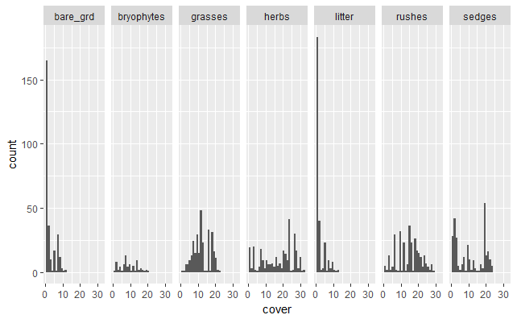

```r
ggplot(cover_data, aes(x = cover)) +
  geom_histogram() +
  facet_grid(facets = ~taxon)
```

not looking particularly normal

### Anderson Darling test

Anderson Darling composite test for normality: **if the p-value is < 0.05 then reject hypothesis that the distribution is normal**

```r
ad.test(x = cover_data$cover[which(cover_data$taxon == "rushes")])
```

```
    Anderson-Darling normality test

data:  cover_data$cover[which(cover_data$taxon == "rushes")]
A = 2.1635, p-value = 1.666e-05
```

nope

```r
ad.test(x = cover_data$cover[which(cover_data$taxon == "grasses")])
```

```
    Anderson-Darling normality test

data:  cover_data$cover[which(cover_data$taxon == "grasses")]
A = 3.5831, p-value = 5.738e-09
```

nope

```r
ad.test(x = cover_data$cover[which(cover_data$taxon == "bryophytes")])
```

```
    Anderson-Darling normality test

data:  cover_data$cover[which(cover_data$taxon == "bryophytes")]
A = 0.74424, p-value = 0.05025
```

well, yes

```r
ad.test(x = cover_data$cover[which(cover_data$taxon == "sedges")])
```

```
    Anderson-Darling normality test

data:  cover_data$cover[which(cover_data$taxon == "sedges")]
A = 15.607, p-value < 2.2e-16
```

no way

```r
ad.test(x = cover_data$cover[which(cover_data$taxon == "herbs")])
```

```
    Anderson-Darling normality test

data:  cover_data$cover[which(cover_data$taxon == "herbs")]
A = 7.1731, p-value < 2.2e-16
```

nah

So basically, violates normality.

oh, wait, lets transform: start again:

plot data

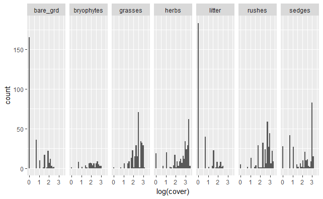

```r
ggplot(cover_data, aes(x = log(cover))) +
  geom_histogram() +
  facet_grid(facets = ~taxon)
```

hard to say

### Anderson Darling test

Anderson Darling composite test for normality: **if the p-value is < 0.05 then reject hypothesis that the distribution is normal**

```r
ad.test(x = log(cover_data$cover[which(cover_data$taxon == "rushes")]))
```

```
    Anderson-Darling normality test

data:  log(cover_data$cover[which(cover_data$taxon == "rushes")])
A = 12.682, p-value < 2.2e-16
```

nope

```r
ad.test(x = log(cover_data$cover[which(cover_data$taxon == "grasses")]))
```

```
    Anderson-Darling normality test

data:  log(cover_data$cover[which(cover_data$taxon == "grasses")])
A = 7.2081, p-value < 2.2e-16
```

nope

```r
ad.test(x = log(cover_data$cover[which(cover_data$taxon == "bryophytes")]))
```

```
    Anderson-Darling normality test

data:  log(cover_data$cover[which(cover_data$taxon == "bryophytes")])
A = 2.2671, p-value = 8.359e-06
```

worse

```r
ad.test(x = log(cover_data$cover[which(cover_data$taxon == "sedges")]))
```

```
    Anderson-Darling normality test

data:  log(cover_data$cover[which(cover_data$taxon == "sedges")])
A = 16.298, p-value < 2.2e-16
```

no way

```r
ad.test(x = log(cover_data$cover[which(cover_data$taxon == "herbs")]))
```

```
    Anderson-Darling normality test

data:  log(cover_data$cover[which(cover_data$taxon == "herbs")])
A = 22.026, p-value < 2.2e-16
```

noope